DaliScope — WorkedExample2: HTML example output

Saved output from DaliScope v0.1.9 for Supplementary Text ST2. The GOLD core contains 6,465 targets in 23 communities. The Pfam heatmaps group rows by their peak module, then by descending peak count. The v0.1.9 notebook uses the original row order.

Python-backed controls require the notebook. Embedded 3D views depend on an external viewer and browser WebGL support.

# Setup

In **Google Colab**, run the setup cell below: it downloads the versioned repository, installs DaliScope, and enables custom widgets. No local Python or Conda installation is needed. Use a standard CPU runtime.

In **local Jupyter**, install DaliScope using the root README and select **Python (DaliScope)**. If you update packages in an existing local session, restart the kernel once.

Run cells in order. The analysis setup locates the repository and sets the working directory to `notebooks` for relative data paths. See the [Colab guide](https://github.com/Liisa-Holm-group/DaliScope/blob/v0.1.9/docs/colab.md) for saving outputs and restarting a cloud runtime.

```python
# In Colab this installs DaliScope automatically. Locally, follow the README first.
import sys
from pathlib import Path
import subprocess
import runpy

try:
    import google.colab
except ModuleNotFoundError as error:
    if error.name not in {"google", "google.colab"}:
        raise
    IN_COLAB = False
else:
    IN_COLAB = True

if IN_COLAB:
    DALISCOPE_RELEASE = "v0.1.9"
    colab_root = Path("/content/DaliScope")
    if not colab_root.exists():
        subprocess.run([
            "git", "clone", "--depth", "1", "--branch", DALISCOPE_RELEASE,
            "https://github.com/Liisa-Holm-group/DaliScope.git", str(colab_root),
        ], check=True)
    setup_path = colab_root / "scripts/colab_setup.py"
    if not setup_path.is_file():
        raise RuntimeError("This runtime contains an older checkout. Start a fresh runtime and run setup again.")
    setup = runpy.run_path(str(setup_path))
    setup["setup_colab"](colab_root, DALISCOPE_RELEASE)
else:
    print("Local Jupyter: using the installed DaliScope environment.")
```

```
Local Jupyter: using the installed DaliScope environment.
```

```python
from pathlib import Path
import os

ROOT = Path.cwd().resolve()
if not (ROOT / "daliscope").is_dir():
    ROOT = ROOT.parent
if not (ROOT / "daliscope").is_dir():
    raise RuntimeError("Start in the DaliScope root or notebooks directory")
os.chdir(ROOT / "notebooks")
import daliscope
print("DaliScope", daliscope.__version__, "from", Path(daliscope.__file__).resolve())
```

```
DaliScope 0.1.9 from ...\DaliScope-0.1.9\daliscope\__init__.py
```

```python
import pandas as pd
from IPython.display import display

import daliscope
import daliscope.core.project
import daliscope.optics.histograms
import daliscope.analysis.data_preview
import daliscope.analysis.occupancy
import daliscope.analysis.structal_similarity # for cluster evaluation
import daliscope.widgets.pairwise_py3Dmol
import daliscope.optics.modules_sunburst
import daliscope.analysis.communities
import daliscope.analysis.pfam_stats

from daliscope.analysis.data_preview import show_heading
```

# Worked Example: Fish-Eye View of Fold Space Around a GOLD-like Domain with Jelly-Roll Topology

*Using DaliScope functions*

## Background

GOLD domains (Pfam clan CL0521) are small β-sandwich modules — eight strands arranged in two sheets, adopting a jelly-roll topology related to the Nucleoplasmin-like/VP fold — found across a functionally coherent family of proteins involved in Golgi trafficking. We use a representative GOLD-like domain as the query for this worked example: PDB entry 5TDQ, chain A, Golgi resident protein GCP60.

## Search strategy

A DALI search with transitive closure against the AlphaFold Protein Structure Database v2 (AFDB2) returned over 12,000 hits for this query. We selected a shared core of secondary-structure elements to focus the analysis on the jelly-roll region.

## The fish-eye problem

A DALI search ranks each hit by a Z-score measuring its structural similarity *to the query*. This is a radial measurement — it tells you how far each point sits from the center, but nothing about how the points relate to *each other*. The resulting picture is a fish-eye view: everything is placed relative to a single vantage point, and two hits that are highly similar to one another can appear on opposite sides of the query with no indication that they're related at all. This is a real limitation once a fold turns out — as this one does — to be shared across many distinct superfamilies: radial distance from the query cannot, by construction, distinguish "many independent instances of the same superfamily" from "several structurally distinct superfamilies that each merely resemble the query."

## Approach: the Rigid Core Pipeline

To move beyond this single-vantage-point view, we used DaliScope's Rigid Core Pipeline: comparison of the selected hits with each other (not just with the query) using voxel fingerprints of their Cα traces in the common DALI frame, followed by Infomap community detection on the resulting nearest-neighbour similarity network. This identifies communities of mutually similar structures without using Pfam annotations. We then compare the communities with Pfam classifications to see which are dominated by particular domain families or clans.

## What this document covers

Working from this community structure, we:

- visualize the overall hit landscape and a Pfam-colored scatterplot of the search results;
- filter to the domain-relevant population and run the fingerprint/Infomap community analysis described above and evaluate the communities with pairwise STRUCTAL scores;
- compare communities with Pfam annotations and inspect selected modules through recursive analysis, domain architecture cartoons, and structural superimposition.

Together, these steps organize a large query-centred hit set into structural communities and place Pfam-unassigned targets in the context of annotated domains. Assigning molecular functions to those targets requires independent evidence.

# Raw Dali data

On loading the data, DaliScope presents a static scatterplot in the (Z-score, query-coverage) plane. These are the two main measures of alignment quality. They are generally correlated. DALI scores reflect similarities in intramolecular distances; for a fixed number of aligned residues, a closer structural match generally gives a higher Z-score.

The plot uses colour coding for

- sequence identity regimes
- Z-score regimes

Z-score regimes are based on heuristic thresholds - they usually work for "typical cases". Empirically, Dali Z-scores rank hits in reasonable agreement with expert-curated manual classifications like SCOP. However, the optimal classification thresholds differ from one query structure to another, depending on the shape and size of the protein.

Sequence identity regimes indicate what could be found by traditional sequence search (homologs), where structural alignment improves alignment quality (twilight) and where it is indispensable (dark).

Loading data

```
Pack loaded: 7622616 coord rows, 122647 segments, 12316 alignments, Query.pdb: yes
```

```
  Superimpositions: 12245/12245 succeeded
  Pfam: 12245/12245 alignments assigned
```

```
  Pfam domains: 11543/12245 targets
  Clan domains: 11543/12245 targets
```

```
  Pileups: 12245 sequ, 12245 dssp
Silver built: 12245 alignments (71 dropped), query length=123
```

```
✓ Registered 'dom_0-123': 12245 alignments
  Default view 'dom_0-123' registered
```

Top hits

|  | Target | Z-Score | RMSD | aln_len | Description | % Id |
| --- | --- | --- | --- | --- | --- | --- |
| 5 | e7w5A | 23.1 | 0.6 | 123 | HUMAN:AF-Q9H3P7-F1 GOLGI RESIDENT PROTEIN GCP60; | 98 |
| 3 | gfqjA | 22.9 | 0.6 | 123 | MOUSE:AF-Q8BMP6-F1 GOLGI RESIDENT PROTEIN GCP60; | 95 |
| 16 | c4n4A | 22.3 | 0.6 | 123 | DANRE:AF-Q5RHP5-F1 ACYL-COENZYME A-BINDING DOMAIN-CONTAINING 3; | 92 |

Creating filtered subsets

```
  Subset 'FILTERED_0': 11943/12245 rows
  Subset 'FILTERED_1': 3779/12245 rows
```

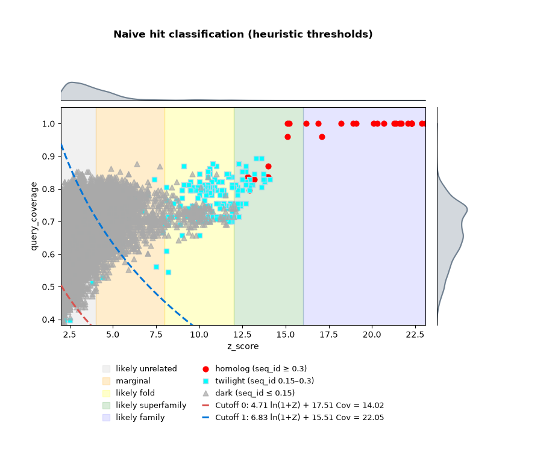

```python
# Load data
# Colab fetches this optional release asset automatically and checks its SHA-256.
pack_path = 'data/GOLD.tar.gz'
if IN_COLAB:
    subprocess.run([sys.executable, str(ROOT / "scripts/download_example.py"),
                    "GOLD", "--tag", DALISCOPE_RELEASE], check=True)
if not Path(pack_path).is_file():
    raise FileNotFoundError('GOLD pack is optional. See data/README.md for release download instructions.')

# 1. Initialize & Preview Top Hits
project, FULL_DF, FULL_VIEW = daliscope.analysis.data_preview.load_and_inspect_project(pack_path)

# 2. Plot Landscape
fig = daliscope.analysis.data_preview.plot_dali_hits_with_boundaries(
    FULL_DF,
    daliscope.analysis.data_preview.build_and_register_subsets(project, FULL_DF, FULL_VIEW)
)
```

The plot shows a typical mix of sequence identity regimes: homologs have the highest Z-scores, followed by twilight hits. The large peak with dark hits can contain genuine biologically interesting hits, and noise.

DaliScope automatically created two subsets which bisect the plane at valleys in the density distribution. Sometimes - but far from always - the subsets correspond to families or superfamilies. These automatically generated subsets are called FILTERED_0 and FILTERED_1.

# Domain-clipped superimposition and occupancy-based selection

Dali alignments optimize intramolecular distance similarity, but aligned residues outside a shared structural core can disrupt a rigid-body fit. The secondary-structure heatmap below helps locate the coherent core: blue helices, red strands, and green loops reveal where different targets align.

We use **PDB residues 23–123, inclusive** as the core. The clipping cell converts this to `22-123` in the zero-based, half-open API. Community detection converts the stored clipping range back to one-based inclusive residues, so the two steps use the same 101 query positions.

Clipping excludes aligned residues outside this core. DaliScope then recomputes a **uniform least-squares superimposition** over the retained aligned residues. Separately, the `dom_FOLD` subset uses a position-occupancy-weighted score with cutoff 0.8 to select targets. This cutoff is a threshold on that score, not a requirement for 80% unweighted residue coverage; selection does not reweight or refit the coordinates.

dom_0-123 ( n = 12245 )

```
Initializing heavy assets...
```

```
Generating RGB Heatmap array...
```

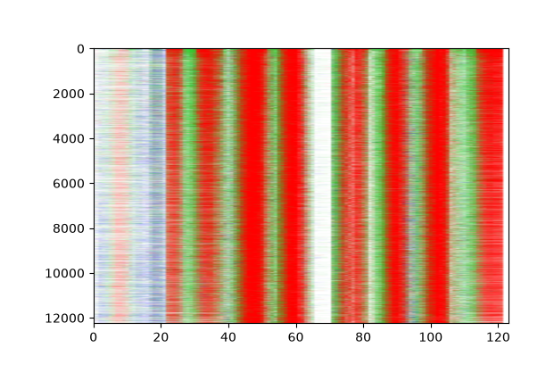

```
✓ Registered 'dom': 12245 alignments
  Subset 'dom_FOLD': 6465/12245 rows
```

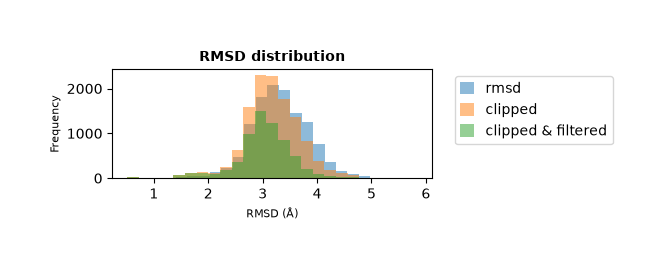

```python
# 3. Project structural alignments onto Query positions
project.viz.plot_msa(FULL_VIEW, 0, 123, plot_type='heatmap', data_col='dssp_pileup')

# 2. Preserve the stated PDB structural core in the clipping convention.
from daliscope.mechanics.domain_ranges import pdb_domain_string_to_clipping, clipping_ranges_to_pdb
core_pdb_domains = "23-123"
daliscope.mechanics.metrics.register_multiple_domains(
    domain_string=pdb_domain_string_to_clipping(core_pdb_domains), project=project, custom_name="dom",
)

# 3. Register filtered FOLD subset.
daliscope.analysis.occupancy.create_fold_subset(project, 'dom', show_plot=False, cutoff=0.8)

# 4. Compare RMSD in raw Dali data, after domain clipping, and after FOLD occupancy filtering
df = FULL_DF[['target_id','rmsd']].copy()
df['clipped & filtered'] = project.views['dom_FOLD']['rmsd']
df['clipped'] = project.views['dom']['rmsd']
daliscope.optics.histograms.plot_overlaid_distributions(
    [df['rmsd'], df['clipped'], df['clipped & filtered']],
    figsize=(6,2),
    title='RMSD distribution',
    xlabel='RMSD (Å)'
)
```

# Play with the structures

The Query structure is blue, the target is red. Thick lines and dashed lines show the raw Dali alignment, but the least-squares superimposition uses the clipped aligned residues with uniform weights.

```python
daliscope.widgets.pairwise_py3Dmol.generate_superimposition_view(
    target_ix=216,
    df=project.views['dom_FOLD'],
    project=project,
    q_ca_coords=project.query_ca_coords,
    target_ca_coords=project.coords,
)
```

[Rendered Structure Target IX: 216] **ID:** h2ylA | **Align ID:** 246  
**Z-score:** 10.20 | **RMSD:** 1.91 Å | **Len:** 90 | **SeqID:** 24.4%  
*SOYBN:AF-I1KP02-F1 UNCHARACTERIZED PROTEIN;*

3Dmol.js failed to load for some reason. Please check your browser console for error messages.

```
<py3Dmol.view at 0x27b0f689eb0>
```

# What do existing domain classifications tell us?

Here, we show the Pfam family and superfamily (clan) assignments of the domain-fold populations.

The table links family and clan identifiers to InterPro documentation. The clan descriptions confirm that these populations include jellyroll folds, a common structural topology.

A notable fraction of the targets lack Pfam assignments despite structural similarity to the domain fold, as shown by the current “Unassigned” count below. Such gaps in domain classification occur even among targets with high Z-scores. In the domain cartoons, these targets appear as empty dashed red boxes; in the scatterplot, they appear as green dots dispersed among known GOLD-like domains (CL0521).

These gaps in domain classification motivate a complementary question: **what structural communities exist within the domain-fold population, independent of sequence or existing annotation?**

```python
# 1. Table view
daliscope.analysis.pfam_stats.pfam_counts('dom_FOLD', project, k=10, print_tables = True)
```

```
Largest families in 'dom_FOLD' population (n=6465):
```

| pfam | count | clan | clan_short | short | name |
| --- | --- | --- | --- | --- | --- |
| Unassigned | 1176 | NaN | NaN | NaN | NaN |
| [PF00622](https://www.ebi.ac.uk/interpro/entry/pfam/PF00622/) | 510 | [CL0004](https://www.ebi.ac.uk/interpro/set/pfam/CL0004/) | Concanavalin | SPRY | SPRY domain |
| [PF00431](https://www.ebi.ac.uk/interpro/entry/pfam/PF00431/) | 266 | [CL0164](https://www.ebi.ac.uk/interpro/set/pfam/CL0164/) | CUB | CUB | CUB domain |
| [PF01105](https://www.ebi.ac.uk/interpro/entry/pfam/PF01105/) | 264 | [CL0521](https://www.ebi.ac.uk/interpro/set/pfam/CL0521/) | GOLD-like | EMP24_GP25L | emp24/gp25L/p24 family/GOLD |
| [PF13640](https://www.ebi.ac.uk/interpro/entry/pfam/PF13640/) | 245 | [CL0029](https://www.ebi.ac.uk/interpro/set/pfam/CL0029/) | Cupin | 2OG-FeII_Oxy_3 | 2OG-Fe(II) oxygenase superfamily |
| [PF12819](https://www.ebi.ac.uk/interpro/entry/pfam/PF12819/) | 226 | [CL0202](https://www.ebi.ac.uk/interpro/set/pfam/CL0202/) | GBD | Malectin_like | Malectin-like domain |
| [PF00722](https://www.ebi.ac.uk/interpro/entry/pfam/PF00722/) | 195 | [CL0004](https://www.ebi.ac.uk/interpro/set/pfam/CL0004/) | Concanavalin | Glyco_hydro_16 | Glycosyl hydrolases family 16 |
| [PF00139](https://www.ebi.ac.uk/interpro/entry/pfam/PF00139/) | 180 | [CL0004](https://www.ebi.ac.uk/interpro/set/pfam/CL0004/) | Concanavalin | Lectin_legB | Legume lectin domain |
| [PF00386](https://www.ebi.ac.uk/interpro/entry/pfam/PF00386/) | 117 | [CL0100](https://www.ebi.ac.uk/interpro/set/pfam/CL0100/) | C1q_TNF | C1q | C1q domain |
| [PF00754](https://www.ebi.ac.uk/interpro/entry/pfam/PF00754/) | 90 | [CL0202](https://www.ebi.ac.uk/interpro/set/pfam/CL0202/) | GBD | F5_F8_type_C | F5/8 type C domain |

```
Largest superfamilies in 'dom_FOLD' population:
```

| clan | count | clan_short |
| --- | --- | --- |
| [CL0202](https://www.ebi.ac.uk/interpro/set/pfam/CL0202/) | 1585 | GBD |
| [CL0004](https://www.ebi.ac.uk/interpro/set/pfam/CL0004/) | 1485 | Concanavalin |
| Unassigned | 1176 | NaN |
| [CL0029](https://www.ebi.ac.uk/interpro/set/pfam/CL0029/) | 763 | Cupin |
| [CL0521](https://www.ebi.ac.uk/interpro/set/pfam/CL0521/) | 417 | GOLD-like |
| [CL0164](https://www.ebi.ac.uk/interpro/set/pfam/CL0164/) | 285 | CUB |
| [CL0100](https://www.ebi.ac.uk/interpro/set/pfam/CL0100/) | 164 | C1q_TNF |
| [CL0055](https://www.ebi.ac.uk/interpro/set/pfam/CL0055/) | 112 | Nucleoplasmin |
| [CL0612](https://www.ebi.ac.uk/interpro/set/pfam/CL0612/) | 46 | PHM_PNGase_F |
| PF05986 | 43 | NaN |

dom_FOLD (n=6465)

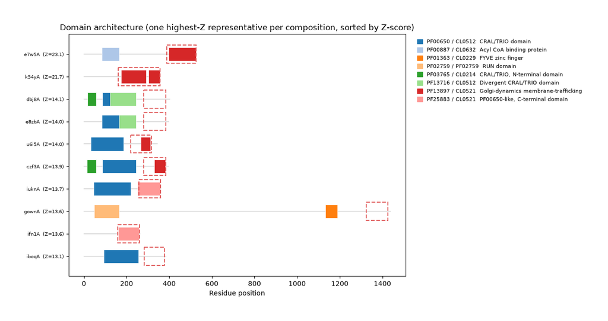

```python
# 2. Domain architecture cartoons
project.viz.architecture('dom_FOLD', renderer='matplotlib', pfam_col='pfam_domains')
```

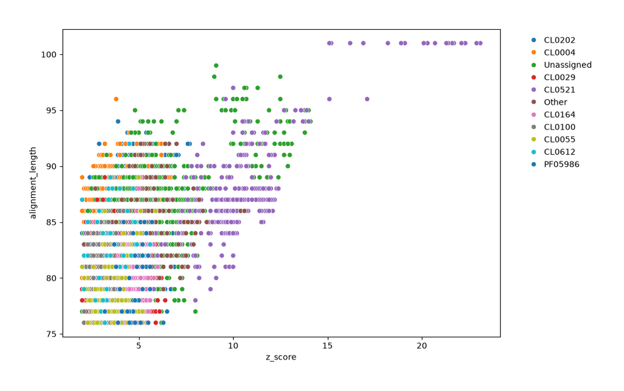

```python
# 3. Scatterplot colored by Pfam clan categories
df = project.views['dom_FOLD'][['alignment_length', 'z_score', 'clan', 'pfam']].copy()
df["clan_label"] = daliscope.analysis.pfam_stats.top_category_label(df, "clan", k=10)

fig = daliscope.optics.histograms.plot_scatter(
    df, x='z_score', y='alignment_length', color='clan_label', engine='matplotlib',
)
display(fig)
figure_dir = ROOT / "results" / "worked-example2"
figure_dir.mkdir(parents=True, exist_ok=True)
fig.savefig(figure_dir / "GOLD_scatter.png", dpi=300, bbox_inches="tight")
```

# Community detection

*Note.* The recorded run printed “Running 1293000 pairwise STRUCTAL alignments”. The number is 6,465 targets × 200 requested neighbours per target. The timing labelled “Alignment” measures voxel-fingerprint neighbour retrieval. Infomap partitions the resulting fingerprint network. Pairwise STRUCTAL scores are computed afterwards to evaluate its communities (Supplementary Methods S4–S6 and S8).

```
Running build_structural_fingerprint_index ...
```

```
Running 1293000 pairwise STRUCTAL alignments ...
Runtime depends on the selected population, structure sizes, and hardware.
```

```
Timings (sec): Index=1.75s, Alignment=278.83s, Graph=0.46s | Total=281.04s
```

```
  Subset 'dom_FOLD_module_1': 339/6465 rows
  Subset 'dom_FOLD_module_2': 934/6465 rows
  Subset 'dom_FOLD_module_3': 744/6465 rows
  Subset 'dom_FOLD_module_4': 609/6465 rows
  Subset 'dom_FOLD_module_5': 569/6465 rows
  Subset 'dom_FOLD_module_6': 239/6465 rows
  Subset 'dom_FOLD_module_7': 337/6465 rows
  Subset 'dom_FOLD_module_8': 86/6465 rows
  Subset 'dom_FOLD_module_9': 471/6465 rows
  Subset 'dom_FOLD_module_10': 134/6465 rows
  Subset 'dom_FOLD_module_11': 171/6465 rows
  Subset 'dom_FOLD_module_12': 176/6465 rows
  Subset 'dom_FOLD_module_13': 90/6465 rows
  Subset 'dom_FOLD_module_14': 592/6465 rows
  Subset 'dom_FOLD_module_15': 63/6465 rows
  Subset 'dom_FOLD_module_16': 58/6465 rows
  Subset 'dom_FOLD_module_17': 270/6465 rows
  Subset 'dom_FOLD_module_18': 287/6465 rows
  Subset 'dom_FOLD_module_19': 83/6465 rows
  Subset 'dom_FOLD_module_20': 22/6465 rows
  Subset 'dom_FOLD_module_21': 76/6465 rows
  Subset 'dom_FOLD_module_22': 114/6465 rows
  Subset 'dom_FOLD_module_23': 1/6465 rows
Successfully generated 23 module subsets in project.views.
```

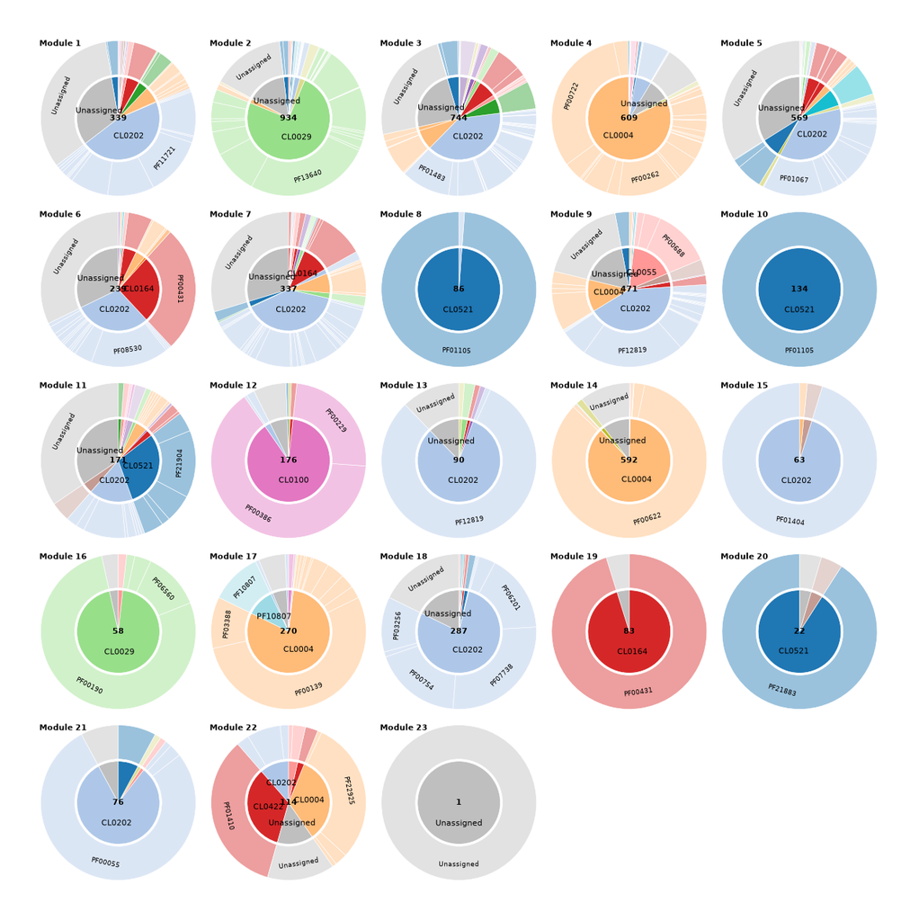

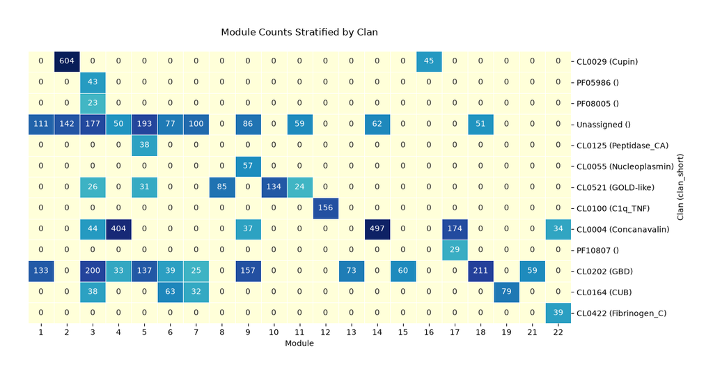

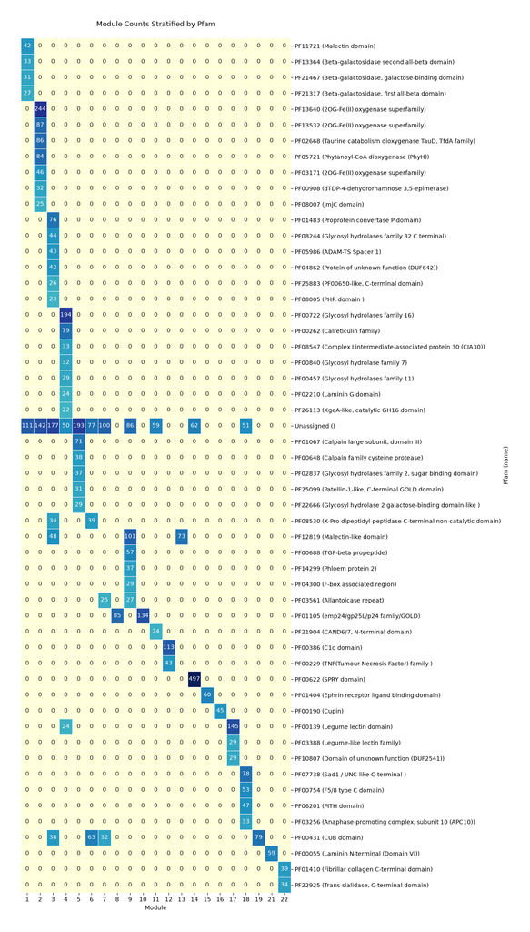

```python
# Run Rigid Core Pipeline
# Use the same physical query residues as the clipped view.
community_ranges = clipping_ranges_to_pdb(project.provenance["dom"].parameters["domain_ranges"])

# Call community detection function across dom_FOLD
modules_df, n_modules = daliscope.analysis.communities.run_community_detection(
    view_name="dom_FOLD",
    domain_range=community_ranges,
    project=project,
    k_neighbors=200,
    max_workers=1,
    verbose=True,
)

# Sunburst diagrams. Colors are recycled after 18 clans
fig, axes, clan_colors = daliscope.optics.modules_sunburst.plot_module_sunbursts(
    modules_df,
    modules=range(1, n_modules+1),
)

# Cross-tabulating Pfam categories and modules
daliscope.analysis.communities.module_pfam_table(project, modules_df, row_group='clan', min_count=20)
daliscope.analysis.communities.module_pfam_table(project, modules_df, row_group='pfam', min_count=20)

# Module IDs are run-specific. Choose representatives by current annotation counts.
def representative_module(column, accession):
    counts = modules_df.loc[modules_df[column] == accession].groupby("module").size()
    if counts.empty:
        return None
    return int(counts.sort_values(ascending=False, kind="stable").index[0])


def recurse_annotation_module(column, accession):
    module_id = representative_module(column, accession)
    if module_id is None:
        print(f"No current module has {column}={accession}; skipping recursion.")
        return
    selected_view = f"dom_FOLD_module_{module_id}"
    if len(project.views[selected_view]) < 2:
        print(f"{selected_view} has fewer than two targets; skipping recursion.")
        return
    show_heading(f"{selected_view}: most targets annotated {column}={accession}")
    child_modules, n_child_modules = daliscope.analysis.communities.run_community_detection(
        view_name=selected_view, domain_range=community_ranges, project=project,
        k_neighbors=200, max_workers=1, verbose=True,
    )
    daliscope.optics.modules_sunburst.plot_module_sunbursts(
        child_modules, modules=range(1, n_child_modules + 1), figsize=(8, 2),
    )
    display(child_modules[["module", "pfam", "clan"]].value_counts().rename("count").reset_index())
```

## Ten largest structural modules

The following cartoon overview shows the ten modules with the most targets in **this run**. Module numbers can change if the data, clipping, or clustering parameters change. Exported PNGs are saved under `results/worked-example2`, which is included in the Colab results ZIP.

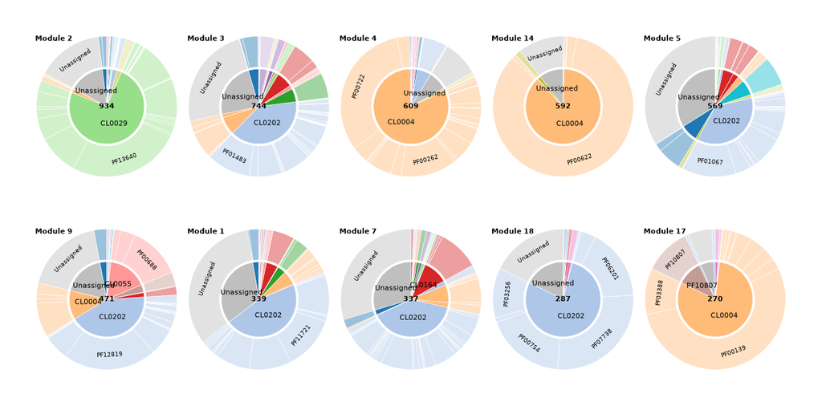

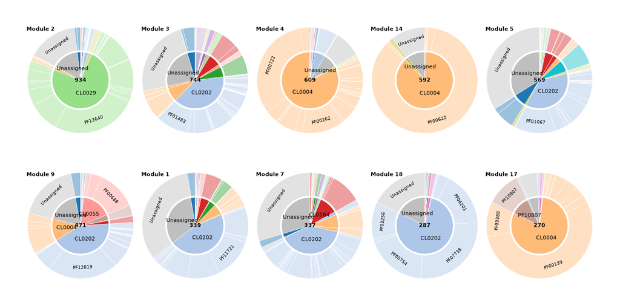

```python
# Liisa Holm's ten-module overview, selected by current module size.
largest_module_ids = (
    modules_df["module"].value_counts().head(10).index.astype(int).tolist()
)
if largest_module_ids:
    fig, axes, clan_colors = daliscope.optics.modules_sunburst.plot_module_sunbursts(
        modules_df, modules=largest_module_ids, figsize=(12, 6),
    )
    display(fig)
    figure_dir = ROOT / "results" / "worked-example2"
    figure_dir.mkdir(parents=True, exist_ok=True)
    fig.savefig(figure_dir / "ten_largest_modules.png", dpi=300, bbox_inches="tight")
else:
    print("No modules were detected; skipping the overview.")
```

## Recursive splitting

Inspect whether selected modules remain cohesive or split into finer structural populations. Module numbers are assigned by the current Infomap run and are not fixed biological labels.

The following cells select the module with the most current **CL0100 (C1q_TNF)** annotations and the module with the most **PF17065** annotations. Ties use the lowest module ID. They display the new submodule annotations; missing annotations or fewer than two targets are explicitly skipped. Compare these outputs to assess structural coherence. Selection by annotation guides inspection and does not establish a shared function for every member.

dom_FOLD_module_12: most targets annotated clan=CL0100

```
Running build_structural_fingerprint_index ...
Running 35200 pairwise STRUCTAL alignments ...
Runtime depends on the selected population, structure sizes, and hardware.
Timings (sec): Index=0.02s, Alignment=0.11s, Graph=0.00s | Total=0.14s
```

```
  Subset 'dom_FOLD_module_12_module_1': 176/176 rows
Successfully generated 1 module subsets in project.views.
```

|  | module | pfam | clan | count |
| --- | --- | --- | --- | --- |
| 0 | 1 | PF00386 | CL0100 | 113 |
| 1 | 1 | PF00229 | CL0100 | 43 |
| 2 | 1 | Unassigned | Unassigned | 12 |
| 3 | 1 | PF06366 | CL0202 | 3 |
| 4 | 1 | PF00431 | CL0164 | 2 |
| 5 | 1 | PF01105 | CL0521 | 1 |
| 6 | 1 | PF04300 | CL0202 | 1 |
| 7 | 1 | PF14273 | PF14273 | 1 |

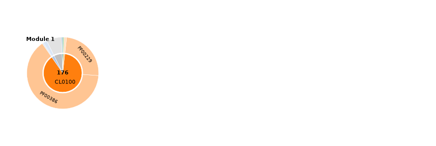

```python
recurse_annotation_module("clan", "CL0100")
```

dom_FOLD_module_14: most targets annotated pfam=PF17065

```
Running build_structural_fingerprint_index ...
Running 118400 pairwise STRUCTAL alignments ...
Runtime depends on the selected population, structure sizes, and hardware.
```

```
Timings (sec): Index=0.19s, Alignment=2.66s, Graph=0.03s | Total=2.89s
```

```
  Subset 'dom_FOLD_module_14_module_1': 592/592 rows
Successfully generated 1 module subsets in project.views.
```

|  | module | pfam | clan | count |
| --- | --- | --- | --- | --- |
| 0 | 1 | PF00622 | CL0004 | 497 |
| 1 | 1 | Unassigned | Unassigned | 62 |
| 2 | 1 | PF07177 | CL0004 | 13 |
| 3 | 1 | PF17065 | PF17065 | 8 |
| 4 | 1 | PF12248 | CL0004 | 5 |
| 5 | 1 | PF13765 | CL0004 | 3 |
| 6 | 1 | PF03712 | CL0612 | 1 |
| 7 | 1 | PF12143 | CL0890 | 1 |
| 8 | 1 | PF07081 | CL0004 | 1 |
| 9 | 1 | PF10333 | PF10333 | 1 |

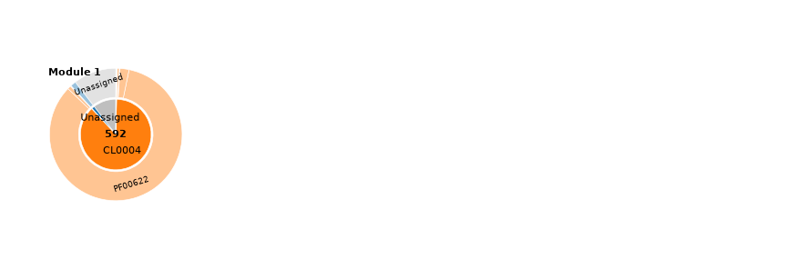

```python
recurse_annotation_module("pfam", "PF17065")
```

Other registered module views can be inspected by selecting their current annotations or view names. Reuse `community_ranges` when running additional community analyses.

## How structurally distinct are the modules?

The following box plot compares sampled within- and between-module STRUCTAL scores. For each module, the left box shows within-module scores and the right box shows between-module scores. This is a descriptive comparison: no significance test is performed here, and differences in sample composition can affect the distributions. The recursive analysis above separately checks whether selected modules split at finer resolution.

```
[apply_transforms] sanity check over 6465 targets: median aligned-core RMSD = 3.20 A (range 0.56-5.99).
  Typical refined-superposition RMSD should be a few A. If this is instead tens/hundreds of A, the R/t convention is probably transposed -- try `local_coords @ R + t` or `(R @ local_coords.T).T + t` instead.
```

```
[evaluate_module_cohesion] evaluating 23 modules, up to 2000+8000 pairs each (~230,000 STRUCTAL calls worst case -- actual may be less for small modules)
```

```
[evaluate_module_cohesion] 1/23 modules done
```

```
[evaluate_module_cohesion] 2/23 modules done
```

```
[evaluate_module_cohesion] 3/23 modules done
```

```
[evaluate_module_cohesion] 4/23 modules done
```

```
[evaluate_module_cohesion] 5/23 modules done
```

```
[evaluate_module_cohesion] 6/23 modules done
```

```
[evaluate_module_cohesion] 7/23 modules done
```

```
[evaluate_module_cohesion] 8/23 modules done
```

```
[evaluate_module_cohesion] 9/23 modules done
```

```
[evaluate_module_cohesion] 10/23 modules done
```

```
[evaluate_module_cohesion] 11/23 modules done
```

```
[evaluate_module_cohesion] 12/23 modules done
```

```
[evaluate_module_cohesion] 13/23 modules done
```

```
[evaluate_module_cohesion] 14/23 modules done
```

```
[evaluate_module_cohesion] 15/23 modules done
```

```
[evaluate_module_cohesion] 16/23 modules done
```

```
[evaluate_module_cohesion] 17/23 modules done
```

```
[evaluate_module_cohesion] 18/23 modules done
```

```
[evaluate_module_cohesion] 19/23 modules done
```

```
[evaluate_module_cohesion] 20/23 modules done
```

```
[evaluate_module_cohesion] 21/23 modules done
```

```
[evaluate_module_cohesion] 22/23 modules done
```

```
[evaluate_module_cohesion] 23/23 modules done
```

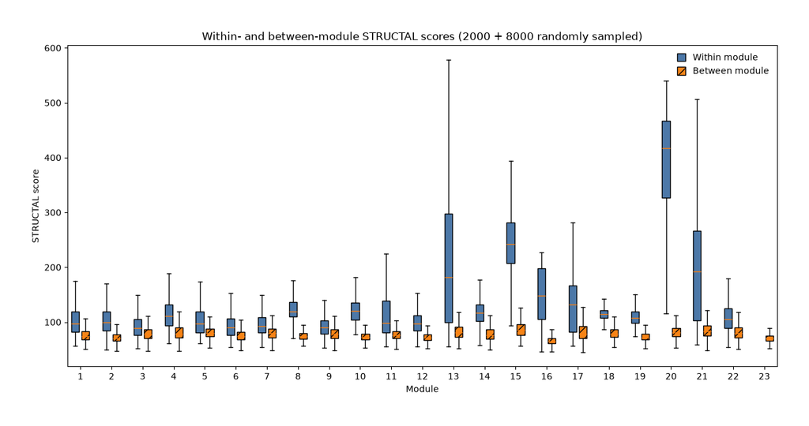

```python
# Descriptive comparison of sampled pairwise STRUCTAL scores between and within modules
_summary_df, raw_scores = daliscope.analysis.structal_similarity.evaluate_module_cohesion(
    project, 'dom_FOLD', modules_df,
    n_within=2000, n_between=8000,
    modules=None,  # or None for everything, with the cost warning
)

# Box-plot
fig, ax = daliscope.analysis.communities.plot_module_score_distributions(
    raw_scores=raw_scores,
    figsize=(12, 6),
    title="Within- and between-module STRUCTAL scores (2000 + 8000 randomly sampled)",
)
```

```python
# Release the large per-pair score arrays after drawing the comparison.
import gc
del raw_scores
gc.collect()
```

```
16047
```

# What structural features characterize a population?

We demonstrate domain architecture cartoons and structural superimposition. Use the displayed annotations and target descriptions to interpret each population; the plots alone do not establish molecular function.

## Domain architectures in a structural module

The following cell displays architecture cartoons for one module, selected by its current **CL0521 (GOLD-like)** annotations.

dom_FOLD_module_10: representative CL0521 annotations

dom_FOLD_module_10 (n=134)

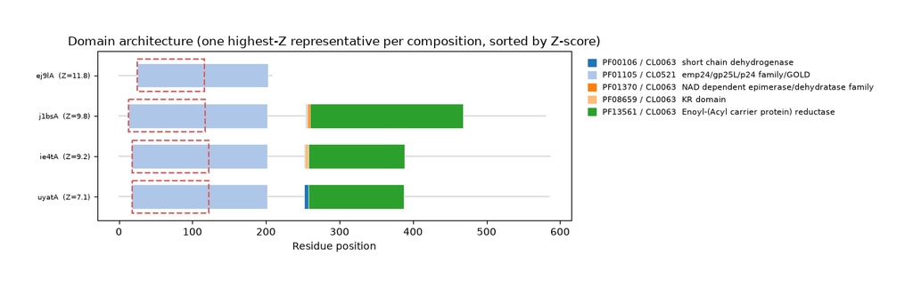

```python
architecture_module_id = representative_module("clan", "CL0521")
if architecture_module_id is None:
    print("No current module has clan=CL0521; skipping architecture cartoon.")
else:
    architecture_view = f"dom_FOLD_module_{architecture_module_id}"
    show_heading(f"{architecture_view}: representative CL0521 annotations")
    project.viz.architecture(
        architecture_view, renderer='matplotlib', pfam_col='pfam_domains',
    )
```

## Transitive superimposition

Select the current module containing the most **PF00190 (Cupin_1)** annotations, rather than relying on a historical module number. PF00190 includes diverse cupin proteins; inspect target descriptions and structures before assigning a specific function such as germin activity.

The cell displays up to five evenly spaced targets in that module. The query is a GOLD-like domain, shown as a thin gray reference trace. Missing annotations are explicitly skipped.

Mouse controls: rotate, zoom, and pan.

```python
import numpy as np

module_id = representative_module("pfam", "PF00190")
if module_id is None:
    print("No current PF00190 module; skipping transitive superimposition.")
else:
    view_name = f"dom_FOLD_module_{module_id}"
    selected_df = project.views[view_name]
    target_ixes = np.linspace(0, len(selected_df) - 1, min(5, len(selected_df)), dtype=int).tolist()
    show_heading(f"{view_name}: representative PF00190 annotation population")
    view = daliscope.widgets.pairwise_py3Dmol.generate_transitive_superimposition_view(
        target_ixes=target_ixes, df=selected_df, project=project,
        target_ca_coords=project.coords, q_ca_coords=project.query_ca_coords,
        query_radius=0.15, show_query=True,
    )
    view.show()
```

dom_FOLD_module_16: representative PF00190 annotation population

[Query Scaffold] **Length:** 123 aa

[Target IX: 0] **ID:** ifzsA | **Align ID:** 6985 | **Z-score:** 6.60 | **RMSD:** 2.66 Å | **Len:** 82/123 | **SeqID:** 12.2%  
*ONCVO/AFDB:AF-A0A044SXR6-F1 Uncharacterized protein UNCHARACTERIZED PROTEIN;*

[Target IX: 14] **ID:** tbtpA | **Align ID:** 6079 | **Z-score:** 4.80 | **RMSD:** 3.03 Å | **Len:** 76/123 | **SeqID:** 5.3%  
*MOLECULE: SPHERULIN-1B;*

[Target IX: 28] **ID:** hfulA | **Align ID:** 6039 | **Z-score:** 4.20 | **RMSD:** 3.13 Å | **Len:** 76/123 | **SeqID:** 5.3%  
*SOYBN:AF-I1MG60-F1 GERMIN-LIKE PROTEIN;*

[Target IX: 42] **ID:** tbukA | **Align ID:** 6033 | **Z-score:** 4.10 | **RMSD:** 2.49 Å | **Len:** 77/123 | **SeqID:** 6.5%  
*MOLECULE: GLUCOSE-6-PHOSPHATE ISOMERASE;*

[Target IX: 57] **ID:** ajmcA | **Align ID:** 6031 | **Z-score:** 3.60 | **RMSD:** 3.46 Å | **Len:** 78/123 | **SeqID:** 6.4%  
*ARATH:AF-P33487-F1 AUXIN-BINDING PROTEIN 1;*

3Dmol.js failed to load for some reason. Please check your browser console for error messages.

## Pairwise structure cartoons

An additional cartoon viewer fetches a target structure from the DALI viewer and displays it beside the query. This cell requires access to that external server. The viewer accepts five-character target IDs, including PDB IDs and DALI's AFDB pseudo IDs. We choose up to three targets from different clans in the **current** `dom_FOLD` view; each printed label refers to the same row used for the cartoon. The examples can differ when clustering changes, and browser rendering can use substantial memory.

```python
import daliscope.optics.pairwise_cartoon as pairwise_cartoon

cartoon_view = project.views["dom_FOLD"]
# The viewer supports five-character IDs: four-character code plus chain.
cartoon_candidates = modules_df.loc[
    modules_df["target_id"].astype(str).str.fullmatch(r"[A-Za-z0-9]{5}")
]
cartoon_representatives = (
    cartoon_candidates.drop_duplicates(subset=["clan"], keep="first").head(3)
)
if cartoon_representatives.empty:
    print("No supported target IDs available for pairwise cartoons.")
for _, representative in cartoon_representatives.iterrows():
    target_ix = int(representative["target_idx"])
    target_row = cartoon_view.iloc[target_ix]
    if target_row["target_id"] != representative["target_id"]:
        raise RuntimeError("Module target and cartoon view are out of sync.")
    print(target_row["clan"], target_row["target_id"], target_row["description"])
    try:
        pairwise_cartoon.pairwise_cartoons(
            cartoon_view, target_ix, project.query_pdb_str,
        )
    except RuntimeError as error:
        print(f"Cartoon unavailable for {target_row['target_id']}: {error}")
```

```
CL0521 e7w5A HUMAN:AF-Q9H3P7-F1 GOLGI RESIDENT PROTEIN GCP60;
```

3Dmol.js failed to load for some reason. Please check your browser console for error messages.

```
Unassigned ctqkA DANRE:AF-A0A2R8RWY9-F1 FYVE AND COILED-COIL DOMAIN AUTOPHAGY ADAPTOR 1B;
```

3Dmol.js failed to load for some reason. Please check your browser console for error messages.

```
CL0202 v0zuA WUCBA/AFDB:AF-A0A3P7DRV2-F1 Laminin EGF-like domain-containing protein LAMININ EGF-LIKE DOMAIN-CONTAINING PROTEIN;
```

3Dmol.js failed to load for some reason. Please check your browser console for error messages.

# Summary of Workflow

In this worked example, we demonstrated how **DaliScope** moves beyond basic homology searching:

1. **Beyond Top Hits:** We explored deep structural alignments rather than relying solely on the single highest-scoring match.
2. **User-Driven Decisions:** You retained full control throughout the workflow—from clipping the structural core and comparing communities to inspecting frozen Pfam annotations and their InterPro links.
3. **Reproducible Output:** The self-contained GOLD data pack, recorded software version, domain boundaries, occupancy cutoff, and clustering parameters make the analysis traceable. Module IDs and external PDB-cartoon availability should be checked on each run.